# Advanced_R_markdown

Saranya

November 10, 2018

```r
knitr::opts_chunk$set(echo = TRUE)
```

```r
library(purrr)
```

**map_chr(returns character), map_lgl(returns logical), map_dbl(returns number)** **first arugument as vector and second arguement as function to be applied on each vector or list elements.**

```r
map_chr(c(5,3,1,4,2), function(x){
  c("one","two","three","four","five")[x]
})
```

```
## [1] "five"  "three" "one"   "four"  "two"
```

```r
map_lgl(c(1,2,3,4,5), function(x){
  x>3
})
```

```
## [1] FALSE FALSE FALSE  TRUE  TRUE
```

```r
map_dbl(c(5,10,25), function(x){
  sqrt(x)
})
```

```
## [1] 2.236068 3.162278 5.000000
```

**map_if() function takes 3 arguments.** **1 - a list or vector containing data,** **2 - a predicate function (only when vector element satisfies this condition, 3rd function will be applied.)** **3 - a function to be applied.** **map_if() always returns a list..**

```r
map_if(c(1:5), function(x){
  x %% 2 ==0
}, function(y){
  y^2
}) %>% unlist()
```

```
## [1]  1  4  3 16  5
```

**map_at() function takes 3 arguments** **1. list or vector** **2. index locations at which the function should be applied** **3. function to be applied.**

```r
map_at(seq(100,500,100), c(1,5), function(x){
  x-50
}) %>% unlist()
```

```
## [1]  50 200 300 400 450
```

**map2_chr() takes 2 vectors as input of equal length and third will be function that should be applied on both**

```r
map2_chr(letters, 1:26, paste0)
```

```
##  [1] "a1"  "b2"  "c3"  "d4"  "e5"  "f6"  "g7"  "h8"  "i9"  "j10" "k11"
## [12] "l12" "m13" "n14" "o15" "p16" "q17" "r18" "s19" "t20" "u21" "v22"
## [23] "w23" "x24" "y25" "z26"
```

```r
map2_chr(c(1:5),c(6:10),sum)
```

```
## [1] "7"  "9"  "11" "13" "15"
```

```r
map2_dbl(c(1:5),c(11:15),sum)
```

```
## [1] 12 14 16 18 20
```

**pmap is similar to map2 but we can have more number of list input elements. #list args should be list of list.**

```r
pmap_chr(list(list(1,2,3),list(10,11,12),list('a','b','c')),paste)
```

```
## [1] "1 10 a" "2 11 b" "3 12 c"
```

**reduce() takes first element of vector and implements the function with second value and result will enter the function with 3rd value and so on.** **the function should take atleast 2 args and returns a vector or list**

```r
reduce(c(1:5), function(x,y){
  #message("X is ",x)
  #message("Y is ",y)
  x+y
})
```

```
## [1] 15
```

```r
reduce_right(c(1:5), function(x,y){
  message("X is ",x)
  message("Y is ",y)
  x+y
})
```

```
## X is 5
```

```
## Y is 4
```

```
## X is 9
```

```
## Y is 3
```

```
## X is 12
```

```
## Y is 2
```

```
## X is 14
```

```
## Y is 1
```

```
## [1] 15
```

**contains() searches for specific element inside a vector -> this is not working** **has_element() also searches for specific element -> this works**

```r
#contains(letters,"a")
#contains(letters, "A")

has_element(c(1,2,3,4,5),5)
```

```
## [1] TRUE
```

**detect returns the vector element which first satifies the predicate function**

```r
detect(10:20, function(x){
  x>18
})
```

```
## [1] 19
```

**detect_index returns the vector index which first satifies the predicate function.**

```r
detect_index(10:20, function(x){
  x>18
})
```

```
## [1] 10
```

```r
detect_index(10:20, function(x){
  x>18
})
```

```
## [1] 10
```

**Filter function** **keep(), discard(), every(), some()**

**returns only the elements which satisfied predicate function**

```r
keep(c(1:10), function(x){
  x %% 5 ==0
})
```

```
## [1]  5 10
```

**returns only the elements which doesn’t satify the predicate function**

```r
discard(c(1:10), function(x){
  x %%5 ==0
})
```

```
## [1] 1 2 3 4 6 7 8 9
```

**returns true only when all elements satifies the condition**

```r
every(c(1:10),function(x){
  x %% 1 ==0
})
```

```
## [1] TRUE
```

```r
every(c(1:10),function(x){
  x %% 2 ==0
})
```

```
## [1] FALSE
```

**returns true if some elements satisfies the condition.**

```r
some(c(1:10),function(x){
  x %% 2 ==0
})
```

```
## [1] TRUE
```

**compose() used to combine any number of functions into one function*

```r
n_unique <- compose(length, unique)

rep(1:5,1:5)
```

```
##  [1] 1 2 2 3 3 3 4 4 4 4 5 5 5 5 5
```

```r
n_unique(rep(1:5,1:5))
```

```
## [1] 5
```

**partial() -> you can specify some of the arguments of a function, and then partial() will return a function that only takes the unspecified arguments.**

```r
mult_three_numbers <- function(x,y,z){
  x*y*z
}

mult_by_15 <- partial(mult_three_numbers, x=3, y=5)

mult_by_15(z=4)
```

```
## [1] 60
```

**walk()**

```r
walk(c("hi","hello","how are you"),message)
```

```
## hi
```

```
## hello
```

```
## how are you
```

**Recursive functions** **fibonnaci series**

```r
fib <- function(n){
  stopifnot(n>0)
  if(n==1){
    0
  } else if(n==2){
    1
  } else{
    fib(n-1)+fib(n-2)
  }
}



fib(1)
```

```
## [1] 0
```

```r
fib(2)
```

```
## [1] 1
```

```r
fib(3)
```

```
## [1] 1
```

```r
fib(4)
```

```
## [1] 2
```

```r
fib(5)
```

```
## [1] 3
```

```r
map_dbl(1:10,fib)
```

```
##  [1]  0  1  1  2  3  5  8 13 21 34
```

**optimizing fibonnaci series**

```r
fib_tbl <- c(0,1,rep(NA,23))

fib_mem <- function(n){
  stopifnot(n>0)
  if(!is.na(fib_tbl[n])){
    fib_tbl[n]
  } else {
    fib_tbl[n-1] <<- fib_mem(n-1)
    fib_tbl[n-2] <<- fib_mem(n-2)
    fib_tbl[n-1] + fib_tbl[n-2]
  }
}

map_dbl(1:10,fib_mem)
```

```
##  [1]  0  1  1  2  3  5  8 13 21 34
```

**comparing fib() and fib_mem() functions**

```r
library(purrr)
library(microbenchmark)
library(tidyr)
library(magrittr)
library(dplyr)
```

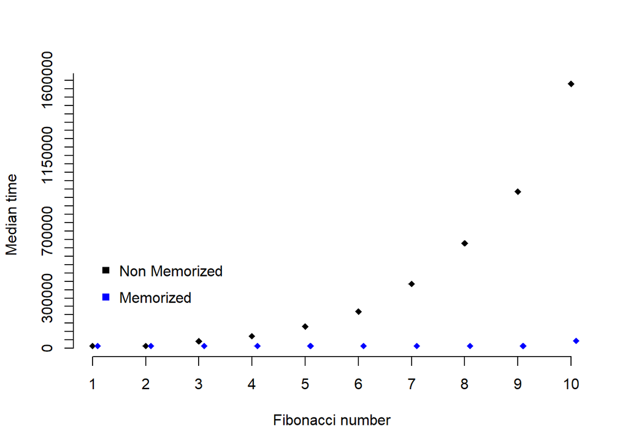

```r
fib_data <- map(1:10,function(x){ microbenchmark(fib(x), times =100)$time })
names(fib_data) <- paste0(letters[1:10],1:10)
fib_data <- as.data.frame(fib_data)

fib_data %<>%
  gather(num, time) %>%
  group_by(num) %>%
  summarise(med_time = median(time))


memo_data <- map(1:10, function(x){ microbenchmark(fib_mem(x),times = 100)$time})
names(memo_data) <- paste0(letters[1:10],1:10)
memo_data <- as.data.frame(memo_data)


memo_data %<>% gather(num, time) %>% group_by(num) %>% summarize(med_val = median(time))


plot(1:10, fib_data$med_time, xlab ="Fibonacci number", ylab ="Median time", pch =18, bty="n", xaxt = "n", yaxt ="n")
axis(1, at = 1:10)
axis(2, at = seq(0,3500000, by=50000))
points(1:10+0.1, memo_data$med_val, col ="blue", pch =18)
legend(1, 600000, c("Non Memorized","Memorized"), pch = 15, col=c("black","blue"),bty="n", cex=1, y.intersp = 1.5)
```

**expressions** **expressions should be mentioned inside quote()**

```r
two_plus_two <- quote(2+2)
```

**expressions can be executed using eval**

```r
eval(two_plus_two)
```

```
## [1] 4
```

**parse() to transform string into expression**

```r
tpt_string <- "2+2"
tpt_expression <- parse(text = tpt_string)
eval(tpt_expression)
```

```
## [1] 4
```

**reverse of parse, transforms expression to string**

```r
deparse(two_plus_two)
```

```
## [1] "2 + 2"
```

**we can modify the contents of expression before evaluation**

```r
sum_expr <- quote(sum(10,50))
sum_expr[1]
```

```
## sum()
```

```r
sum_expr[2]
```

```
## 10()
```

```r
sum_expr[3]
```

```
## 50()
```

```r
eval(sum_expr)
```

```
## [1] 60
```

```r
sum_expr[[1]] <- quote(paste0)
sum_expr[[2]] <- 10
sum_expr[[3]] <- 50
eval(sum_expr)
```

```
## [1] "1050"
```

**we can compose expressions using call()**

```r
new_expr <- call("paste0",1,2)
eval(new_expr)
```

```
## [1] "12"
```

```r
new_expr
```

```
## paste0(1, 2)
```

**match.call() - You can capture the the expression an R user typed into the R console** **when they executed a function by including match.call() in the function the user executed**

```r
return_expr <-  function(...){
  match.call()
}

return_expr(2,col="blue",FALSE) # here while calling the function, whatever parameters are used this will be converted as expression
```

```
## return_expr(2, col = "blue", FALSE)
```

```r
return_expr(2,col="blue",FALSE)
```

```
## return_expr(2, col = "blue", FALSE)
```

**match.call() is used to capture the expression that the user enters. first argument of the expr is evaluated for if it is numeric**

```r
first_arg <- function(...){
  expr <- match.call()
  first_arg_expr <- expr[[2]] # expr[1] corresponds to function name, in this case first_arg
  first_arg <- eval(first_arg_expr)
  if(is.numeric(first_arg)){
    paste("The first argument is", first_arg)
  } else {
    "The first argument is not numeric."
  }
}

first_arg(2,4)
```

```
## [1] "The first argument is 2"
```

```r
first_arg("sara",5)
```

```
## [1] "The first argument is not numeric."
```

**creating new environment** **assign() is used to store values into new environment** **get() is used to retrieve value from new environment, assign() and get() are opposite** **we can assign values to environment like handling list**

```r
my_personal_env <- new.env()
my_personal_env$a <- 100
get("a", envir =  my_personal_env)
```

```
## [1] 100
```

```r
assign("b", 200, envir = my_personal_env)
get("b",envir = my_personal_env)
```

```
## [1] 200
```

**ls() to list variables of environment** **exists() to check if a variable is present in environment** **rm() to remove a variable in environment**

```r
ls(envir = my_personal_env)
```

```
## [1] "a" "b"
```

```r
exists("a",envir = my_personal_env)
```

```
## [1] TRUE
```

```r
rm("b", envir = my_personal_env)
exists("b", envir = my_personal_env)
```

```
## [1] FALSE
```

**environments are organized in parent/child relationship, such that each environment keeps track of its parent but parents are unaware of their children** **search() result indicates, globalenv is child of bindrcpp and bindrcpp is child of dplyr etc**

```r
search()
```

```
##  [1] ".GlobalEnv"             "package:bindrcpp"
##  [3] "package:dplyr"          "package:magrittr"
##  [5] "package:tidyr"          "package:microbenchmark"
##  [7] "package:purrr"          "package:stats"
##  [9] "package:graphics"       "package:grDevices"
## [11] "package:utils"          "package:datasets"
## [13] "package:methods"        "Autoloads"
## [15] "package:base"
```

```r
library(ggplot2)
search()
```

```
##  [1] ".GlobalEnv"             "package:ggplot2"
##  [3] "package:bindrcpp"       "package:dplyr"
##  [5] "package:magrittr"       "package:tidyr"
##  [7] "package:microbenchmark" "package:purrr"
##  [9] "package:stats"          "package:graphics"
## [11] "package:grDevices"      "package:utils"
## [13] "package:datasets"       "package:methods"
## [15] "Autoloads"              "package:base"
```

**after loading ggplot2, this has become parent of globalenv.

**global assignment operator**

```r
a <- 10

my_fun <- function(){
  a<-5
  return(a)
}
my_fun() # returns 5 as the value is from execution environment
```

```
## [1] 5
```

```r
a # a value is still 10
```

```
## [1] 10
```

```r
my_fun_2 <- function(){
  a <<- 5
}

my_fun_2()
a
```

```
## [1] 5
```

```r
#b # no object found
#exists(b)

assign2 <- function(){
  b <<- 25
}
assign2()
#b # returns 25
```

**Error handling**

**stop() to generate an error and stops the execution**

```r
#stop("This is an error")
```

**stopifnot evaluates series of expression and halts the execution if any of the expression is false**

```r
error_function <- function(x){
  stopifnot(x>0)
  print(x)
}

#error_function(-1)
error_function(5)
```

```
## [1] 5
```

**warning() - similar to stop() displays message but doesn’t halt the execution**

```r
warning("This is a warning!")
```

```
## Warning: This is a warning!
```

**messages() -> justs prints the text on screen**

```r
message("hello!")
```

```
## hello!
```

**tryCatch() block** **1st arg - expression to evaluate** **2nd and 3rd args -> error and warning functions** **finally block which executes by default**

```r
my_tryCatch <- function(expr){
  tryCatch(expr,
           error = function(e){
             message("Error occured, ",e)
           },
           warning = function(w){
             message("Warning occured, ",w)
           },
           finally = {
             message("Finally done!")
           })
}
my_tryCatch(sum(10,5))
```

```
## Finally done!
```

```
## [1] 15
```

```r
my_tryCatch(sum(5,"sara"))
```

```
## Error occured, Error in sum(5, "sara"): invalid 'type' (character) of argument
##
## Finally done!
```

```r
my_tryCatch(as.numeric(c(5,"sara")))
```

[output not shown]